# Symptom Severity and Acoustically-Identified Groups of Speakers with and without Autism Spectrum Disorder

Ethan Weed, Riccardo Fusaroli, Jessica Mayo, Inge-Marie Eigsti

## Background

The speech of people with Autism Spectrum Disorder (ASD) has often been described as atypical, but there is little consensus on what acoustic features constitute the atypicality (Fusaroli et al., 2017). This raises the possibility that acoustically-different profiles of atypical speech may exist within ASD speech, as well as the possibility that these profiles may correspond to measures of symptom severity.

## Objectives

Study goals were (1) to identify potential sub-groups of typical and atypical speakers, using acoustic features of prosody and voice, and (2) to investigate how acoustically-identified groups of speakers with and without ASD relate to symptom severity scores on the Social Responsiveness Scale (Constantino & Gruber, 2012).

## Methods

We analyzed speech recordings (8 scripted sentences per participant) from 15 adolescents diagnosed with ASD (mean(SD) age = 14.4 (1.48) years) with IQ scores in the typical range, and 15 adolescents with typical development (TD; mean(SD) age = 14.1(1.91) years); groups did not differ on chronological age or full-scale IQ. Participants in both the ASD and the NT groups demonstrated average to high average performance on standardized language measures (see Mayo, 2015, for details). From these speech recordings, we extracted acoustic measures of prosody and voice quality, and used a community-detection algorithm (Csardi, M. G.,2013; Reichardt & Bornholdt, 2006) to find groups of speakers who shared a common acoustic profile. We then compared these groups on the five subscales of the SRS.

## Results

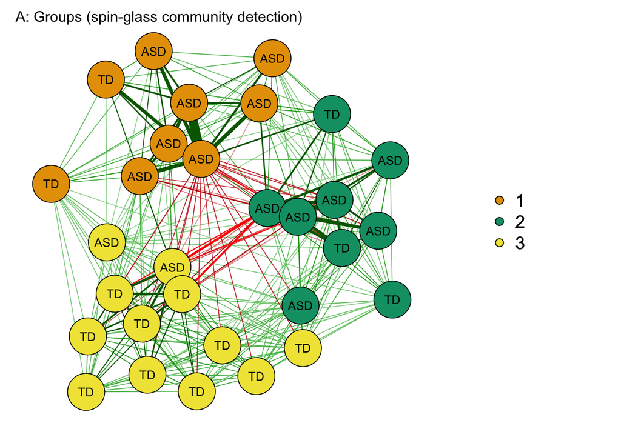

```r
library(qgraph)
library(igraph)
library(tidyverse)

rm(list = ls())

# load and arrange data
df <- read.csv("/Users/ethan/Documents/GitHub/ASD-voice/Paper/data/FullData2.csv")
df_soc <- read.csv("/Users/ethan/Documents/GitHub/ASD-voice/data/Soc_Lang_Database.csv")


df$DX <- ifelse(df$DX == 1, "TD", "ASD")
d <- data.frame("speech_rate" = df$speech_rate,
                "H1H2_SD" = df$H1H2_SD,
                "H1H2" = df$H1H2,
                "articulation_rate" = df$articulation_rate)

# re-arrange data so that participants are nodes (column headers)
d <- t(d)
colnames(d) <- df$ID
d <- as.data.frame(d)
d <- as.data.frame(scale(d))

# graph the network of people
g <-qgraph(cor(d), layout = "spring", repulsion = 5, graph = "pcor", threshold = .03, labels = FALSE, groups = as.factor(df$DX), DoNotPlot = TRUE, title = "DX - partial correlations")

# convert to igraph object for detecting sub-groups
gi <- as.igraph(g)

# run sub-group detection
set.seed(42)
s <- spinglass.community(gi, spins = 10)

# make data frame with person ID and sub-group membership for reference
s2 <- data.frame("ID" = colnames(d),
                 "Community" = s$membership)


# make a data frame with subgroup membership and total SRS scores
Sub_SRS <- s2
Sub_SRS <- rename(Sub_SRS, Group = Community)
Sub_SRS$Group <- factor(Sub_SRS$Group)
Sub_SRS$SRS_total <- df_soc$SRS_Total_T
Sub_SRS$Dx <- factor(df$DX)


# plot the network, adding colors for the sub-groups found by detection algorithm

# colorblind pallette colors for color-coordinating network, bar, and boxplots
fill_colors <- c("#E69F00", "#009E73", "#F0E442", "#56B4E9")


p1 <- qgraph(cor(d), layout = "spring", repulsion = 5, graph = "pcor", threshold = .03, labels = df$DX, groups = as.factor(s2$Community), color = fill_colors, DoNotPlot = FALSE, title = "A: Groups (spin-glass community detection)")

# make hi-res version of plot 1
pdf("//Users/ethan/Documents/GitHub/MOLA2020/Talk/figures/sub-group-graph.pdf")
plot(p1)
dev.off()

plot(p1)
```

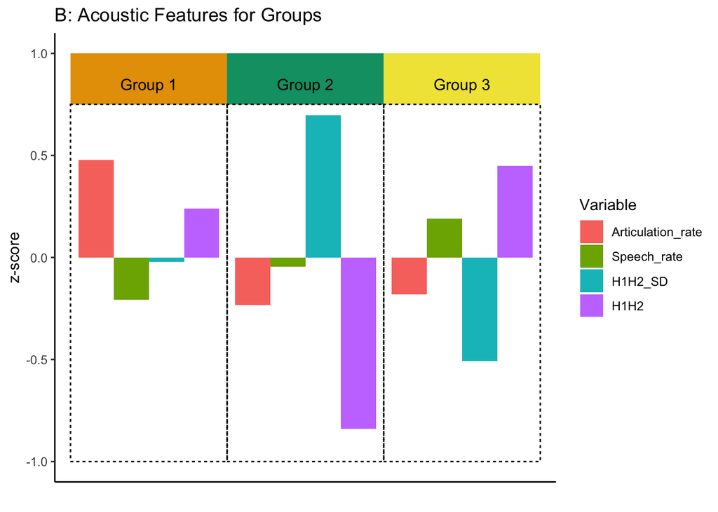

```r
# set up data for plotting bar graph
data <- data.frame("Articulation_rate" = df$articulation_rate,
                "Speech_rate" = df$speech_rate,
                "H1H2_SD" = df$H1H2_SD,
                "H1H2" = df$H1H2)
data <- as.data.frame(scale(data))

data$Community <- s2$Community

Com1 <- colMeans(subset(data, Community == 1))
Com2 <- colMeans(subset(data, Community == 2))
Com3 <- colMeans(subset(data, Community == 3))


Community <- data.frame("SubGroup1" = Com1[1:5],
                        "Subgroup2" = Com2[1:5],
                        "Subgroup3" = Com3[1:5])


C <- data.frame(t(Community))
C$Subgroups <- as.factor(c("Group1", "Group2", "Group3"))
C$Community <- NA

library(reshape2)
C2 <- melt(C)
C2 <- rename(C2, Variable = variable)

# save bar graph as g3 for easy calling below

rect.1 <- data.frame(xmin = 0.5, xmax = 1.5, ymin = .75, ymax = 1)
rect.2 <- data.frame(xmin = 1.5, xmax = 2.5, ymin = .75, ymax = 1)
rect.3 <- data.frame(xmin = 2.5, xmax = 3.5, ymin = .75, ymax = 1)

rect.1a <- data.frame(xmin = 0.5, xmax = 1.5, ymin = -1, ymax = .75)
rect.2a <- data.frame(xmin = 1.5, xmax = 2.5, ymin = -1, ymax = .75)
rect.3a <- data.frame(xmin = 2.5, xmax = 3.5, ymin = -1, ymax = .75)


alpha_level <- 1
outline <- 0
outline2 <- 3

p2 <- ggplot(C2, aes(Subgroups, value)) +
   geom_bar(aes(fill = Variable), position = "dodge", stat="identity") +
   theme_classic() +
   geom_rect(data = rect.1, aes(xmin = xmin, xmax = xmax, ymin = ymin, ymax = ymax),
             fill = fill_colors[1],
             alpha = alpha_level,
             col = "black",
             lty = outline,
             inherit.aes = F) +
   geom_rect(data = rect.2, aes(xmin = xmin, xmax = xmax, ymin = ymin, ymax = ymax),
             fill = fill_colors[2],
             alpha = alpha_level,
             col = "black",
             lty = outline,
             inherit.aes = F) +
   geom_rect(data = rect.3, aes(xmin = xmin, xmax = xmax, ymin = ymin, ymax = ymax),
             fill = fill_colors[3],
             alpha = alpha_level,
             col = "black",
             lty = outline,
             inherit.aes = F) +
   geom_rect(data = rect.1a, aes(xmin = xmin, xmax = xmax, ymin = ymin, ymax = ymax),
             fill = NA,
             alpha = alpha_level,
             col = "black",
             lty = outline2,
             inherit.aes = F) +
   geom_rect(data = rect.2a, aes(xmin = xmin, xmax = xmax, ymin = ymin, ymax = ymax),
             fill = NA,
             alpha = alpha_level,
             col = "black",
             lty = outline2,
             inherit.aes = F) +
   geom_rect(data = rect.3a, aes(xmin = xmin, xmax = xmax, ymin = ymin, ymax = ymax),
             fill = NA,
             alpha = alpha_level,
             col = "black",
             lty = outline2,
             inherit.aes = F) +
  annotate(geom="text", x=1, y=.85, label="Group 1",
              color="black") +
  annotate(geom="text", x=2, y=.85, label="Group 2",
              color="black") +
  annotate(geom="text", x=3, y=.85, label="Group 3",
              color="black") +
  theme(axis.text.x = element_blank(),
        axis.ticks.x = element_blank()) +
  labs(title = "B: Acoustic Features for Groups",
        y = "z-score",
        x = "")


# make hi-res version of plot 2
pdf("/Users/ethan/Documents/GitHub/MOLA2020/Talk/figures/Acoustic-features.pdf")
plot(p2)
dev.off()

plot(p2)
```

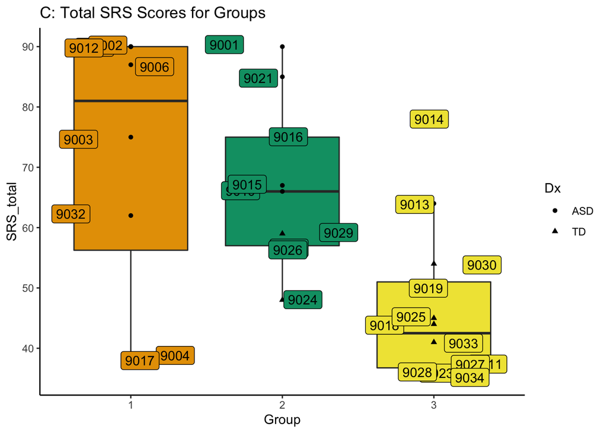

```r
# plot Groups and SRS scores
p3 <- ggplot(Sub_SRS, aes(Group, SRS_total, fill = Group)) +
  geom_boxplot(outlier.size = NULL) +
  scale_fill_manual(values = fill_colors) +
  guides(fill = FALSE) +
  geom_point(aes(shape = Dx)) +
  geom_label(label = Sub_SRS$ID, position = "jitter") +
  theme_classic() +
  labs(title = "C: Total SRS Scores for Groups")

# make hi-res version of plot 3
pdf("/Users/ethan/Documents/GitHub/MOLA2020/Talk/figures/SRS.pdf")
plot(p3)
dev.off()

plot(p3)
```